# Lab 07 - Growth Curve

Michael Dann

October 29, 2014

## Task 1: Load in the data, plot, & guess initial conditions

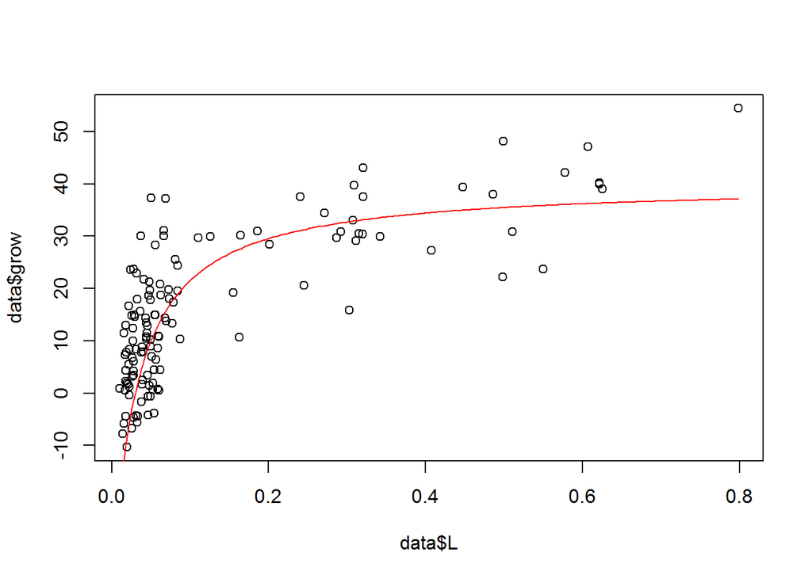

```r
# Load lab7 data and coerce to lab6 format
load("data/Lab7.RData")
library(mvtnorm)
# need an x (L), y (grow), per lab6
# assigned as list elements to "data"

data <- list(L=L, grow=grow)
d <- data # copy for part 2

## initial condition guesses
beta  = c(-40,80)
sg    = 1000
theta = 0.03
zfunc <- function(x,theta){
  return(x/(x+theta))
}
fproc <- function(x,beta, theta){
  if(is.null(dim(beta))){
    y = beta[1]+beta[2]*zfunc(x,theta)
  } else {
    y = beta[,1]+beta[,2]*zfunc(x,theta)
  }
  return(y)
}
Lseq <- seq(min(data$L),max(data$L),length.out = 200)

# visual check
plot(x=data$L,y=data$grow)
lines(Lseq, fproc(Lseq, beta, theta), col=2)
```

```r
## specify priors
append_priors <- function(data, bprior, vinvert,s1,s2,a1,a2){
  # Priors for beta coefs
  data$bprior <-bprior
  data$vinvert <-vinvert

  # sigma priors
  data$s1 <- s1
  data$s2 <- s2

  # Beta distro priors for theta
  data$a1 <- a1
  data$a2 <- a2

  return(data)
}
bprior <- as.vector(c(0,0))
vinvert <- solve(diag(1000,2))
s1 <- 0.1
s2 <- 0.1
a1 <- 1.91
a2 <- 10.17
data <- append_priors(data, bprior, vinvert, s1, s2, a1, a2)

##precompute frequently used quantities
precompute <-function(data, sg, theta){
  data$Vb = data$vinvert %*% data$bprior
  data$sinv <- 1/sg
  data$n <- length(data$L)
  data$z = zfunc(data$L, theta)
  data$X <- cbind(rep(1,data$n),data$z)
  data$theta <- theta
  return(data)
}
data <- precompute(data, sg, theta)
```

## MCMC loop

The core of this analysis is the main loop of the MCMC where we will iteratively draw from the posterior distribution for the regression parameters conditioned on the variance and the variance conditioned on the regression parameters. All of this occurs within a large loop that counts the number of iterations and stores the current value of the parameter values. We’ll begin with the R code for the overall structure of the MCMC and then fill in the details for each sampler

```r
##load libraries
library(coda)
```

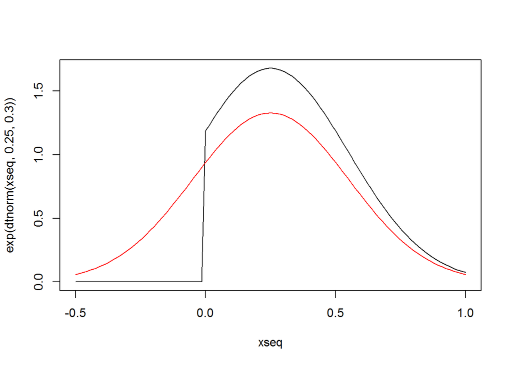

```r
library(mvtnorm)
  dtnorm <- function(x,mu,sd){
    # jump distro
    y = dnorm(x,mu,sd,log=TRUE)-log(pnorm(1,mu,sd)-pnorm(0,mu,sd))
    y[x<0 | x > 1] = -Inf
    return(y)
  }

  # Plot test
  xseq = seq(-0.5,1,length=100)
  plot(xseq,exp(dtnorm(xseq,0.25,0.3)),type='l')
  lines(xseq,dnorm(xseq,0.25,0.3),col=2)
```

```r
gibbs <- function(data, runs=1000, JumpSD){
  data$ngibbs <- runs  ## number of updates
  data$bgibbs <- matrix(beta,nrow=data$ngibbs,ncol=2, byrow = T)    ## storage for beta
  data$vgibbs <- rep(sg, data$ngibbs)           ## storage for sigma2
  data$tgibbs <- rep(theta,data$ngibbs)         ## storage for theta


  rtnorm <- function(n,mu,sd){
    x <- rnorm(n,mu,sd)
    sel <- which(x < 0 | x > 1)
    while(length(sel)> 0){
      x[sel] <- rnorm(length(sel),mu,sd)
      sel <- which(x < 0 | x > 1)
    }
    return(x)
  }
## Gibbs loop
  for(g in 1:data$ngibbs){

    bigV    <- solve(data$sinv*crossprod(data$X) + data$vinvert)
    littlev <- data$sinv*crossprod(data$X,data$grow) + data$Vb
    b <- t(rmvnorm(1,bigV %*% littlev,bigV))

    ## sample variance
    u1 <- data$s1 + data$n/2
    u2 <- data$s2 + 0.5*crossprod(data$grow-data$X%*%b)
    data$sinv <- rgamma(1,u1,u2)
    sg <- 1/data$sinv

    # Sample for theta
    tnew <- rtnorm(1,data$theta,JumpSD)        ##propose new theta
    znew <- data$L/(data$L+tnew)                    ## calculate new z
    Xnew <- cbind(rep(1,data$n),znew)              ## calculate new X
    anum <- dmvnorm(data$grow,Xnew%*%b,diag(sg,data$n),log=TRUE) +  ##likelihood
              dbeta(tnew,data$a1,data$a2,log=TRUE)          ##prior
    jnum <- dtnorm(tnew,data$theta,JumpSD)             ##jump
    aden <- dmvnorm(data$grow,data$X%*%b,diag(sg,data$n),log=TRUE) + ##likelihood
                dbeta(data$theta,data$a1,data$a2,log=TRUE)           ##prior
    jden <- dtnorm(data$theta,tnew,JumpSD)             ##jump
    a <- exp((anum-jnum)-(aden-jden))         ## acceptance criteria
    if(a > runif(1)){                 ## accept with probability a
      data$theta <- tnew                       ## update theta if step accepted
      data$X <- Xnew                       ## update X if step accepted
    }

    ## storage
    data$bgibbs[g,] <- b  ## store the current value of beta vector
    data$vgibbs[g]  <- sg  ## store the current value of the variance
    data$tgibbs[g]  <- data$theta # store the current value of the distribution of theta
  }
  return(data)
}



# output <- gibbs(data, runs=1000, JumpSD=0.1)
# sum(diff(output$tgibbs)==0) # Jump acceptance ~ 15.8% on first run
# output <- gibbs(data, runs=1000, JumpSD=0.05)
# sum(diff(output$tgibbs)==0) # acceptance is ~ 27.6%
# output <- gibbs(data, runs=1000, JumpSD=0.025)
# sum(diff(output$tgibbs)==0) # acceptance is ~ 35.5%
# output <- gibbs(data, runs=1000, JumpSD=0.015)
# sum(diff(output$tgibbs)==0) # acceptance is ~ 45%
burn_demo <- gibbs(data, runs=10000, JumpSD=0.015)
```

## Lab Report Task 2

### Jump Values

I ended up using 0.015 for the standard deviation of the jump distribution.

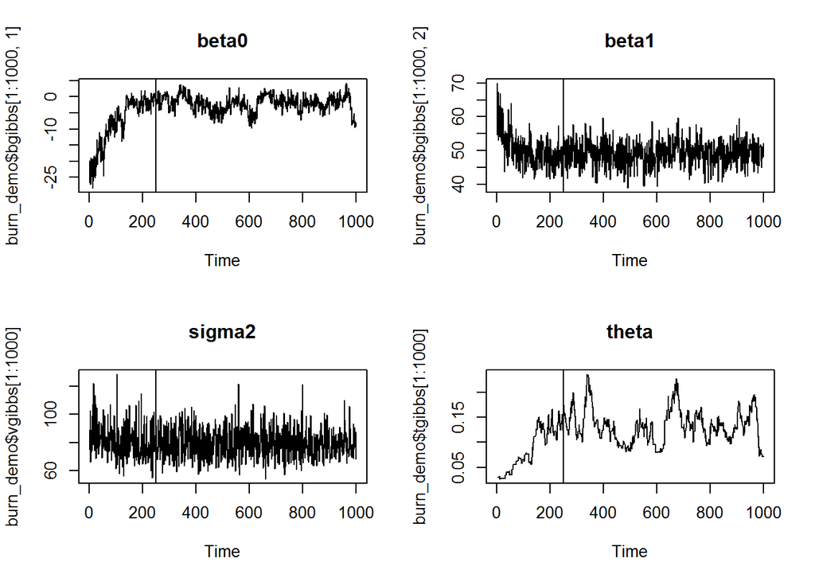

```r
par(mfrow = c(2,2))
ts.plot(burn_demo$bgibbs[1:1000,1], main="beta0");abline(v=250)
ts.plot(burn_demo$bgibbs[1:1000,2], main="beta1");abline(v=250)
ts.plot(burn_demo$vgibbs[1:1000], main="sigma2");abline(v=250)
ts.plot(burn_demo$tgibbs[1:1000], main="theta");abline(v=250)
```

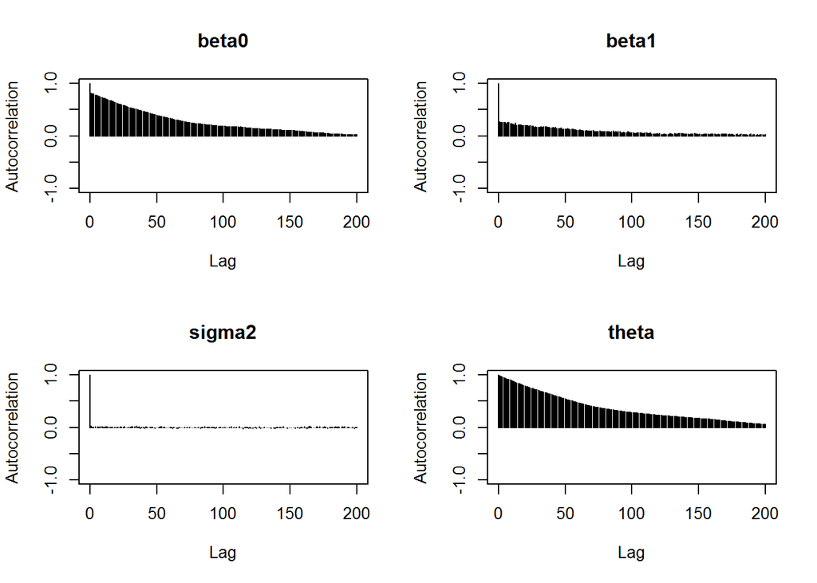

```r
# I chose a burn-in of 250
beg = 250

par(mfrow = c(2,2))
autocorr.plot(burn_demo$bgibbs[beg:10000,1], main="beta0", lag.max = 200, auto.layout = F)
autocorr.plot(burn_demo$bgibbs[beg:10000,2], main="beta1", lag.max = 200, auto.layout = F)
autocorr.plot(burn_demo$vgibbs[beg:10000], main="sigma2", lag.max = 200, auto.layout = F)
autocorr.plot(burn_demo$tgibbs[beg:10000], main="theta", lag.max = 200, auto.layout = F)
```

```r
# I chose to thin out 99 out of every 100th measurement
thin = 100

sample_points = 5000
end = sample_points*thin + beg

# This takes a long-time
output <- gibbs(data, runs=end, JumpSD=0.015)
```

## Diagnostics of the run

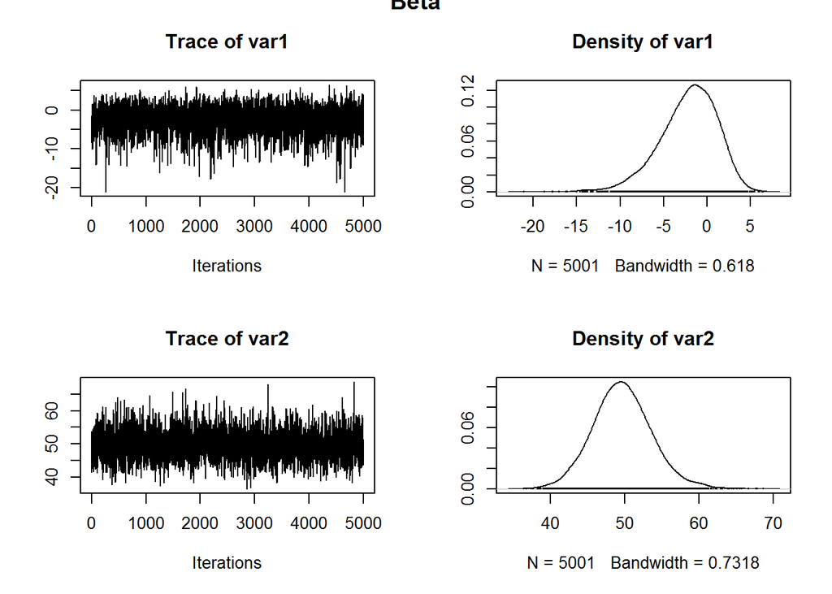

```r
bmcmc <- mcmc(output$bgibbs[seq(beg,end,by=thin),])  ## use beta
vmcmc <- mcmc(output$vgibbs[seq(beg,end,by=thin)])   # use the variance
tmcmc <- mcmc(output$tgibbs[seq(beg,end,by=thin)])  # theta

plot(bmcmc)         ## mcmc history and density plot
title("Beta",outer=T)
```

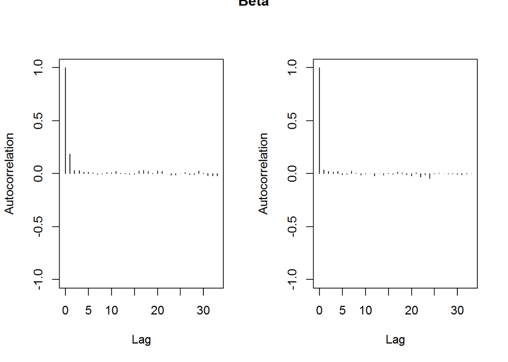

```r
autocorr.plot(bmcmc)        ## autocorrelation
title("Beta",outer=T)
```

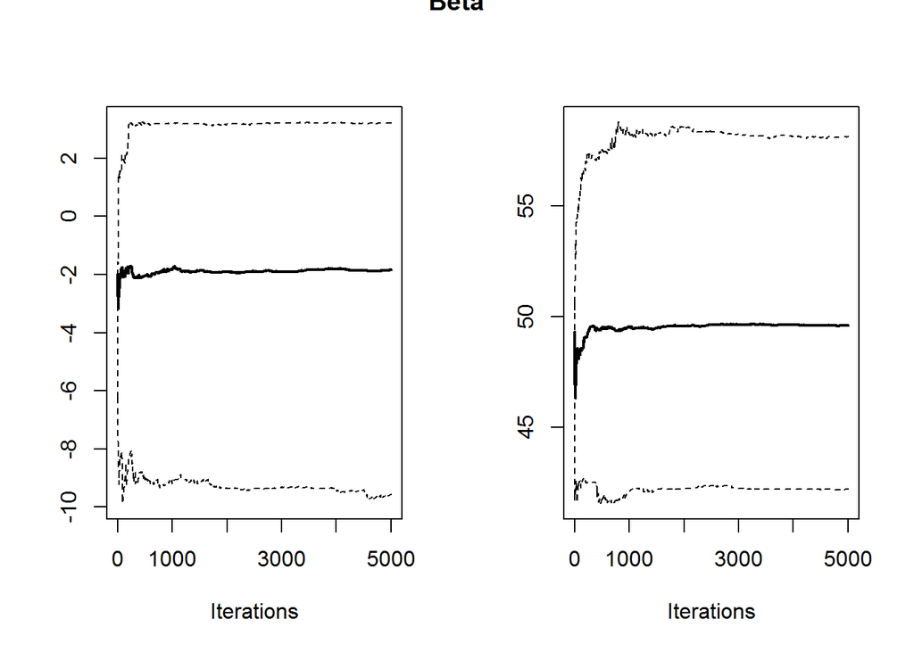

```r
cumuplot(bmcmc)     ## quantile plot
title("Beta",outer=T)
```

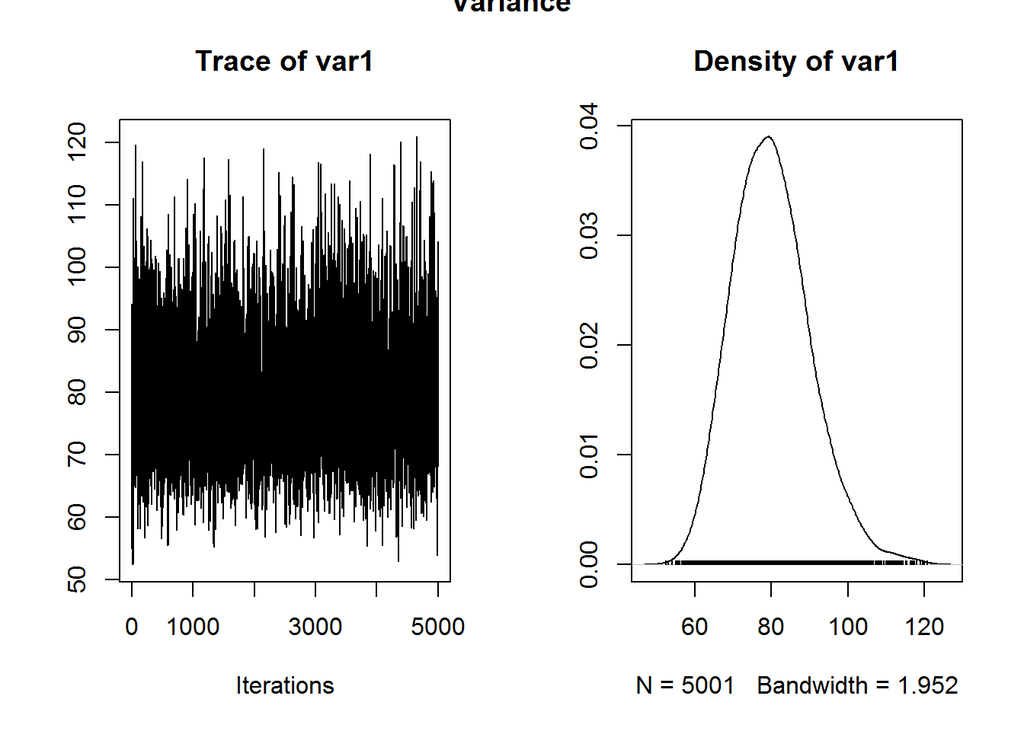

```r
# Variance plots
plot(vmcmc)                 ## mcmc history and density plot
title("Variance",outer=T)
```

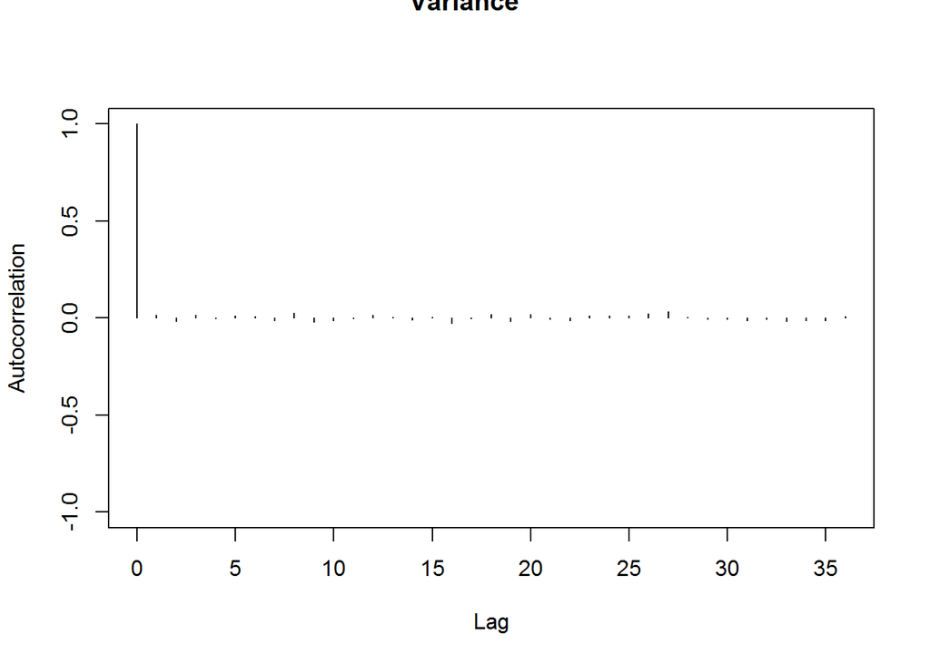

```r
autocorr.plot(vmcmc)        ## autocorrelation
title("Variance",outer=T)
```

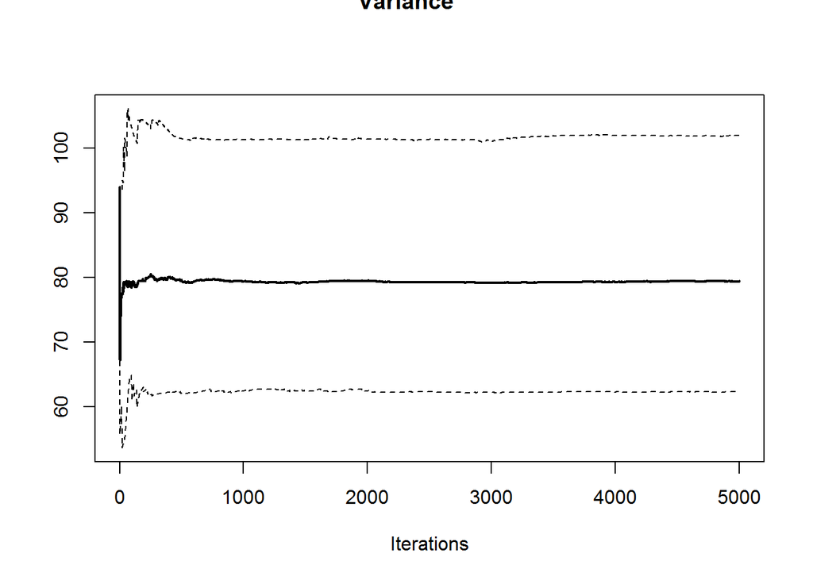

```r
cumuplot(vmcmc)           ## quantile plot
title("Variance",outer=T)
```

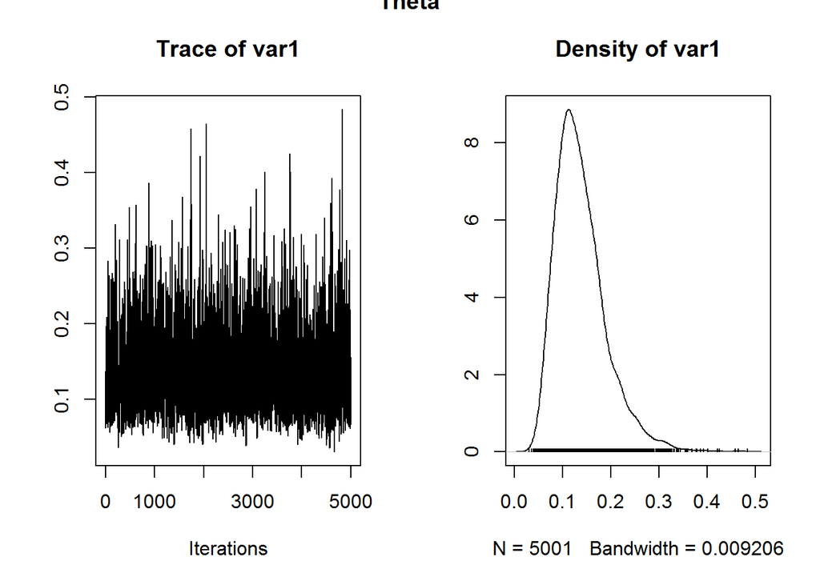

```r
# theta plots
plot(tmcmc)             ## mcmc history and density plot
title("Theta",outer=T)
```

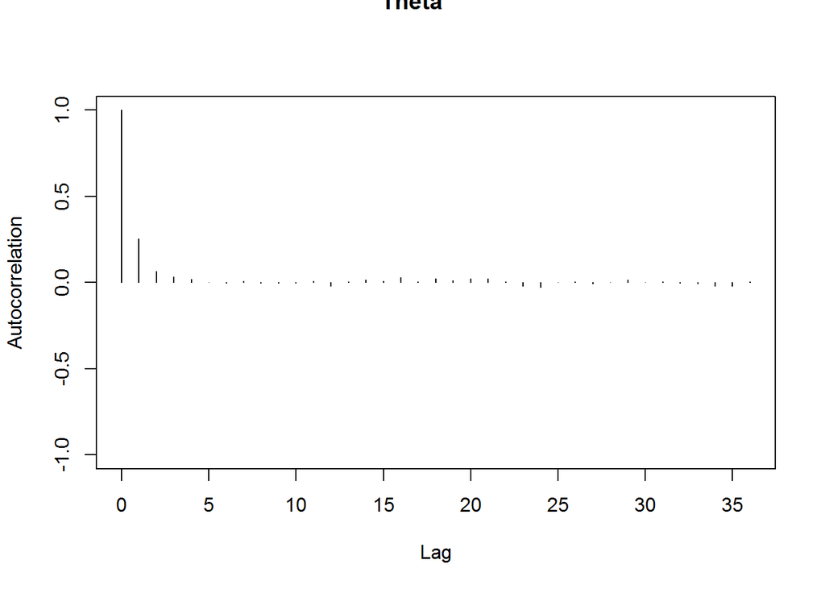

```r
autocorr.plot(tmcmc)        ## autocorrelation, needs thinning
title("Theta",outer=T)
```

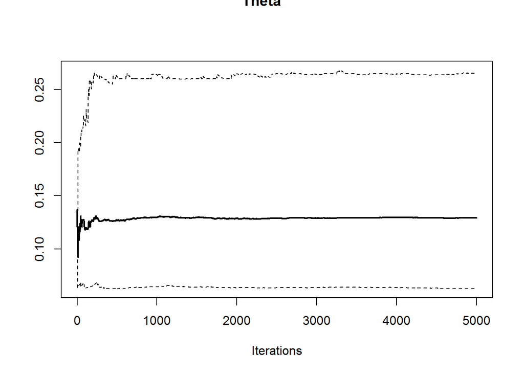

```r
cumuplot(tmcmc)           ## quantile plot
title("Theta",outer=T)
```

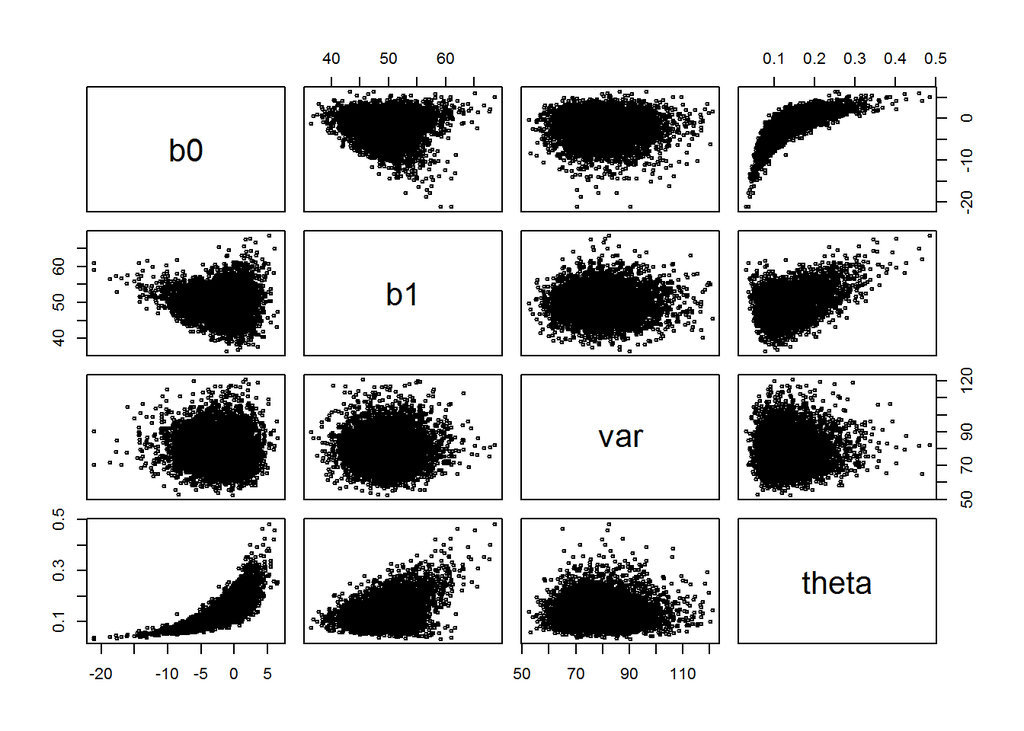

```r
# Correlations
pairs(cbind(b0=bmcmc[,1],b1=bmcmc[,2],var=vmcmc,theta=tmcmc), cex=0.5)
```

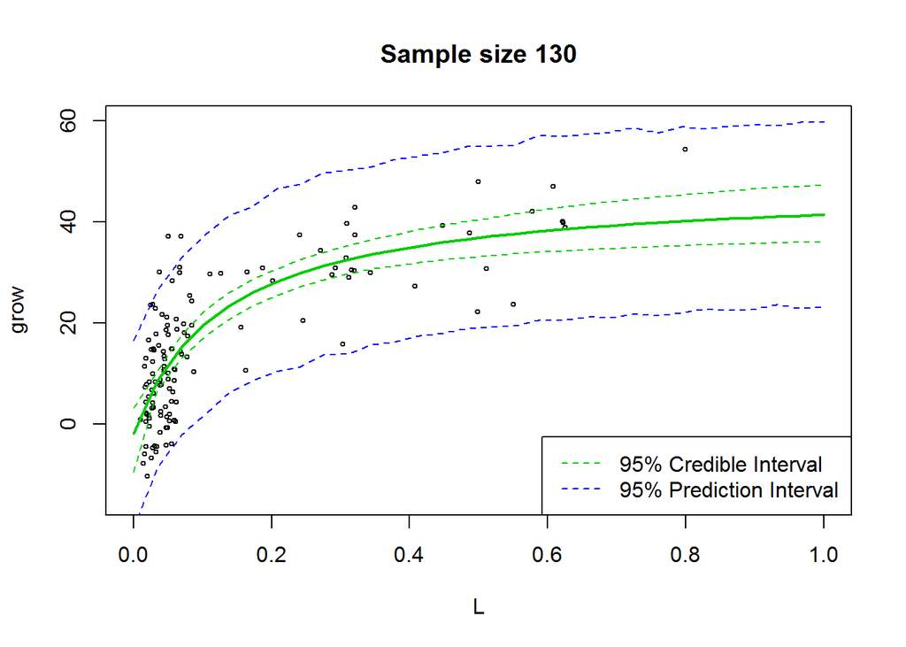

```r
# Credible/Prediction Intervals
credi_predi <- function(data,beg=1, thin=1){
  ## credible and prediction intervals for the mcmc object
  subseq <- seq(from=beg,to=data$ngibbs,by=thin)
  data$xpred <- seq(0,1,length=30)                        ## sequence of x values we're going to
  data$npred <- length(data$xpred)              ##      make predictions for

  data$ypred <- matrix(NA,nrow=length(subseq),ncol=data$npred)  ## storage for predictive interval
  data$ycred <- matrix(NA,nrow=length(subseq),ncol=data$npred)  ## storage for credible interval

  for(g in 1:data$npred){
    data$Ey <- fproc(x = data$xpred[g], beta = data$bgibbs[subseq,], theta  = data$tgibbs[subseq])
    data$ycred[,g] <- data$Ey
    data$ypred[,g] <- rnorm(length(subseq),data$Ey,sqrt(data$vgibbs[subseq]))
  }
  data$ci <- apply(data$ycred,2,quantile,c(0.025,0.5,0.975))  ## credible interval and median
  data$pi <- apply(data$ypred,2,quantile,c(0.025,0.975))        ## prediction interval
  return(data)
}

plot_stuff <- function(data){
  plot(data$L,data$grow,cex=0.5,xlim=c(0,1),ylim=c(-15,60),xlab="L",ylab="grow", main=paste("Sample size", length(data$L)))
  ord <- order(data$xpred) # To ensure compatibility with unordered sample points
  lines(data$xpred[ord],data$ci[1,ord],col=3,lty=2)  ## lower CI
  lines(data$xpred[ord],data$ci[2,ord],col=3,lwd=2)  ## median
  lines(data$xpred[ord],data$ci[3,ord],col=3,lty=2)  ## upper CI
  lines(data$xpred[ord],data$pi[1,ord],col=4,lty=2) ## lower PI
  lines(data$xpred[ord],data$pi[2,ord],col=4,lty=2) ## upper PI
  # abline(b0,b1)               ## true model
  legend("bottomright",legend=c("95% Credible Interval","95% Prediction Interval"),col=c(3,4),lty=c(2,2))
}

table_stuff<-function(data,thin, beg){
  # Table it up
  end = length(data$vgibbs)
  if(is.null(data$sumB)){
    sumB <- summary(mcmc(data$bgibbs[seq(from=beg,to=end, by=thin),]))
  } else {
    sumB <- data$sumB
  }
  if(is.null(data$sumV)){
    sumV <- summary(mcmc(data$vgibbs[seq(from=beg,to=end, by=thin)]))
  }else {
    sumV <- data$sumV
  }
  if(is.null(data$sumT)){
    sumT <- summary(mcmc(data$tgibbs[seq(from=beg,to=end, by=thin)]))
  }else {
    sumT <- data$sumT
  }
  cols_1 <- rbind(sumB[[1]][,1:2], sumV[[1]][1:2],sumT[[1]][1:2])
  cols_2 <- rbind(sumB[[2]], sumV[[2]], sumT[[2]])
  row.names(cols_1) <- NULL
  row.names(cols_2) <- NULL
  df <- data.frame(cbind(cols_1,cols_2))
  names(df)[3:7] <- dimnames(cols_2)[[2]]
  row.names(df) <- NULL
  df <- cbind(Var= c("b0","b1","sigma2","theta"), df)
  df$CI <- df[,"97.5%"]-df[,"2.5%"]
  return(df)
}
tab1 <- table_stuff(output,beg=beg,thin=thin)


# Plot the credible and prediction intervals.
par(mfrow=c(1,1))
output2 <- credi_predi(output, beg=beg, thin=thin)
plot_stuff(output2)
```

```r
# A summary table of parameter estimates
tab1[order(tab1[,"Var"]),]
```

```
##      Var    Mean       SD     2.5%     25%     50%     75%    97.5%
## 1     b0 -2.1868  3.31622 -9.55497 -4.1161 -1.8378  0.1751   3.2023
## 2     b1 49.6952  3.98218 42.21280 47.0622 49.5901 52.1437  58.0984
## 3 sigma2 80.0452 10.18535 62.31889 72.7894 79.4124 86.3453 102.0214
## 4  theta  0.1382  0.05281  0.06247  0.1015  0.1293  0.1654   0.2652
##        CI
## 1 12.7573
## 2 15.8856
## 3 39.7025
## 4  0.2028
```

## Task 3: Implement in BUGS

Burn-in is about 1000 and thin is set to 50 (though this is probably somewhat excessive it ran fast enough). The MCMC was run for 251000 iterations, yielding a sample size of 5001. This took about 2 minutes on my desktop, as opposed to 30 minutes for the R code.

I did not end up using the BUGS tools to plot the predictive/credible intervals. I reused my code from above -plot_stuff()- after importing the data into R.

```
In R:
dput(list(grow=grow,L=L,n=130))
In Bugs:
model{
  beta[1] ~ dnorm(0,0.001)    ## priors
    beta[2] ~ dnorm(0,0.001)
    theta ~ dbeta(1.91,10.17)  # Beta prior on theta
    prec ~ dgamma(0.1,0.1)
    sd <- sqrt(1/prec)

    for(i in 1:n){
        Eg[i] <- beta[1] + beta[2]*L[i]/(theta+L[i])     ## process model
        grow[i] ~ dnorm(Eg[i],prec)     ## data model
        Pg[i]  ~ dnorm(Eg[i],prec)       ## prediction
    }
}
# Data omitted for brevity
```

```r
setwd("C:/Users/mm/Dropbox/Coursework/2014 Fall/GE509/Labs/EE509/data/")
beta <- read.coda("lab_07_beta.txt", index.file = "lab_07_beta_index.txt", thin=50)
```

```
## Abstracting beta[1] ... 5001 valid values
## Abstracting beta[2] ... 5001 valid values
```

```r
theta <- read.coda("lab_07_theta.txt", index.file = "lab_07_theta_index.txt", thin=50)
```

```
## Abstracting theta ... 5001 valid values
```

```r
prec <- read.coda("lab_07_prec.txt", index.file = "lab_07_prec_index.txt", thin=50)
```

```
## Abstracting prec ... 5001 valid values
```

```r
# Already thinned
Eg <- read.coda("lab_07_Eg.txt", index.file = "lab_07_Eg_index.txt")
```

[output not shown]

[output cut: 75 more lines]

[output not shown]

```r
Pg <- read.coda("lab_07_Pg.txt", index.file = "lab_07_Pg_index.txt")
```

[output not shown]

[output cut: 75 more lines]

[output not shown]

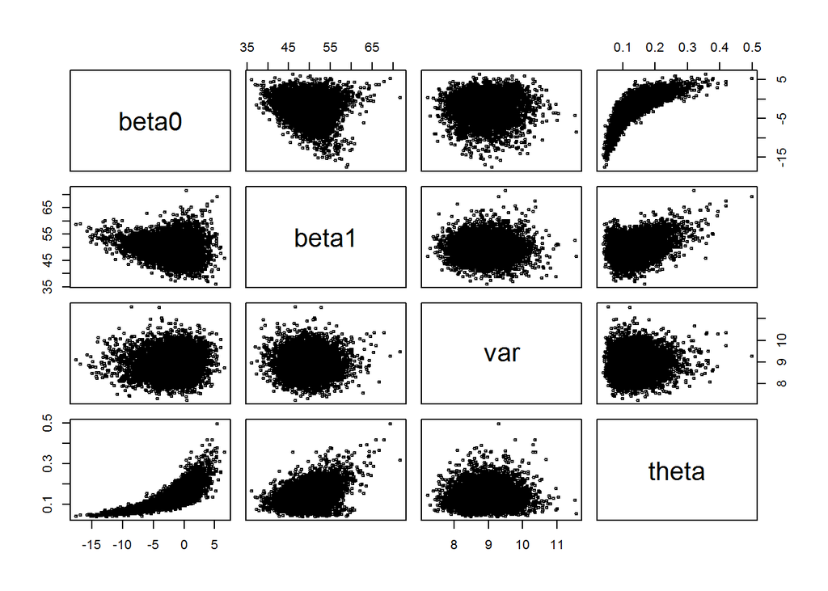

```r
par(mfrow=c(1,1))
pairs(cbind(beta0=beta[,1], beta1=beta[,2], var=1/sqrt(prec[,1]),theta=theta), cex=0.5)
```

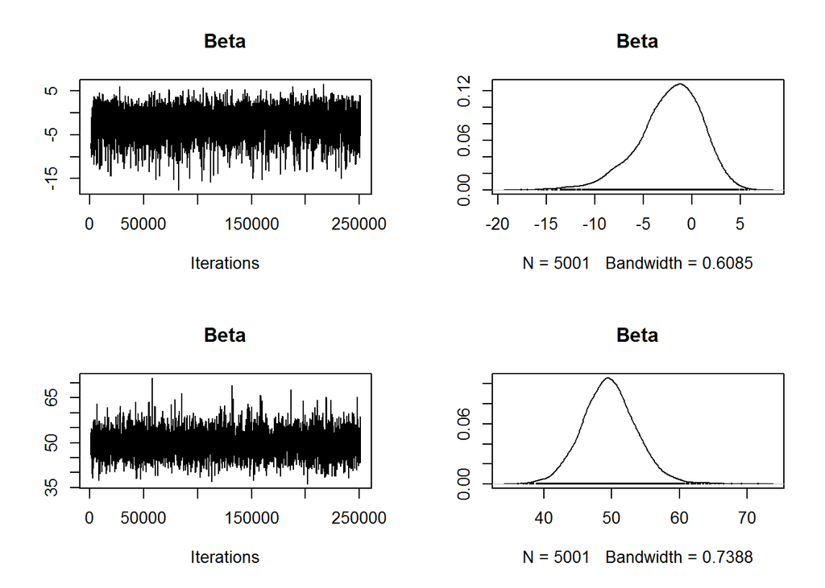

```r
plot(beta, main="Beta")
```

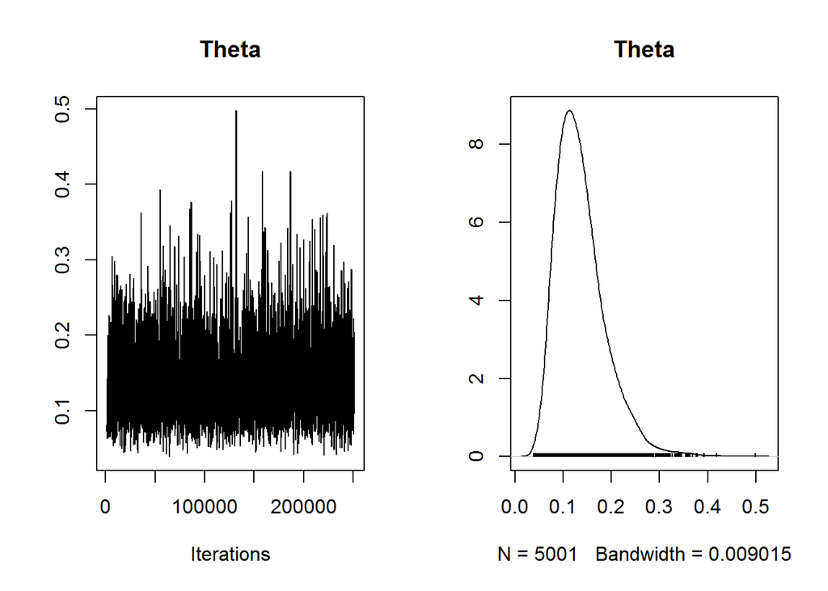

```r
plot(theta, main="Theta")
```

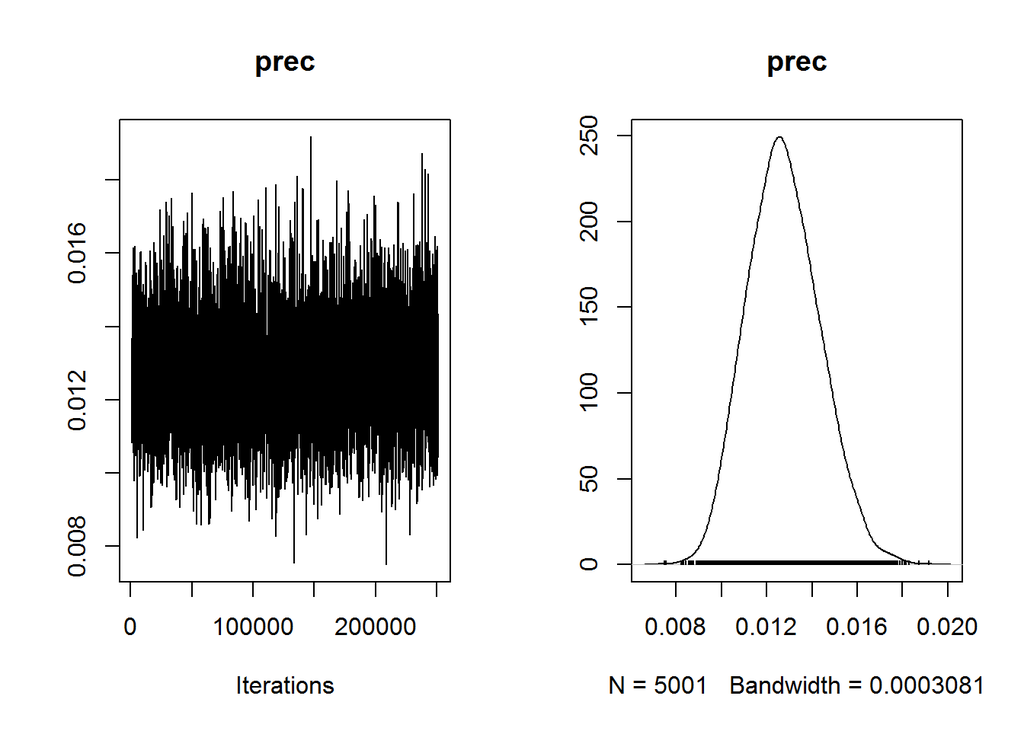

```r
plot(prec, main="prec")
```

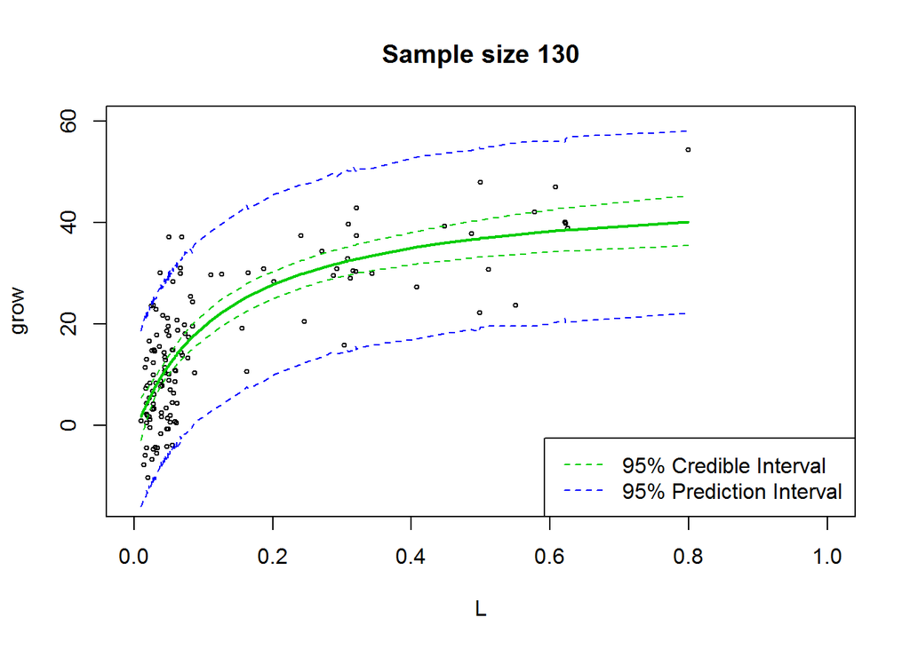

```r
# plot and Compare

# calculate credi/predi and conform to input expected for plot_stuff()
d$xpred <- d$L
d$ci <- apply(data.frame(Eg), 2, quantile, probs = c(0.025, 0.5, 0.975))
d$pi <- apply(data.frame(Pg), 2, quantile, probs = c(0.025, 0.975))
plot_stuff(d)
```

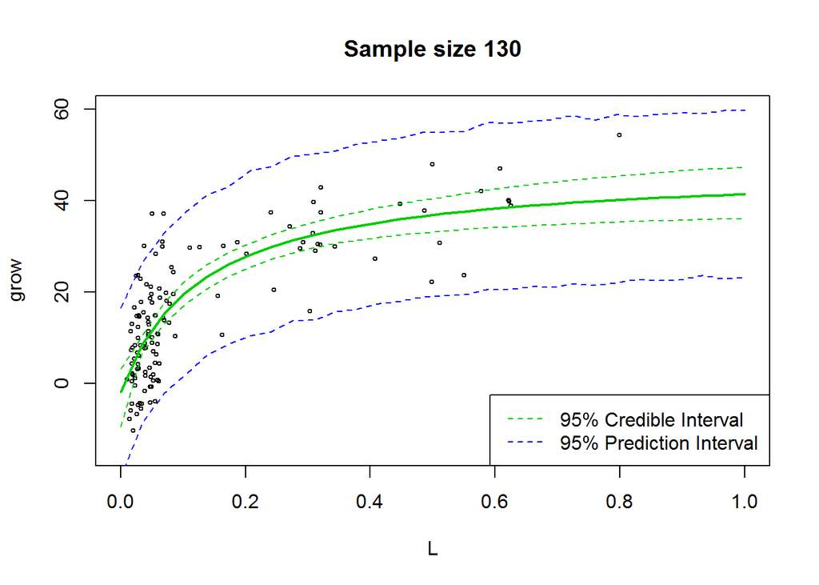

```r
plot_stuff(output2)
```

```r
# conform data to expected input for table_stuff()
d$sumB <- summary(beta)
d$sumV <- summary(1/prec)
d$sumT <- summary(theta)


tab2  <- table_stuff(d, thin=1, beg=1) # Note thin and beg =1 because they are already thinned and begged
tab1  <- cbind(tab1,Method="R")
tab2  <- cbind(tab2, Method="BUGS")
table <- rbind(tab1,tab2)
table[order(table$Var),]
```

```
##      Var    Mean       SD     2.5%     25%     50%     75%    97.5%
## 1     b0 -2.1868  3.31622 -9.55497 -4.1161 -1.8378  0.1751   3.2023
## 5     b0 -2.2307  3.29875 -9.67500 -4.1080 -1.8920  0.1174   3.2250
## 2     b1 49.6952  3.98218 42.21280 47.0622 49.5901 52.1437  58.0984
## 6     b1 49.6353  4.00322 42.01000 46.9900 49.5300 52.1200  57.8800
## 3 sigma2 80.0452 10.18535 62.31889 72.7894 79.4124 86.3453 102.0214
## 7 sigma2 79.6268 10.11546 62.38303 72.4638 78.8644 86.0585 101.3274
## 4  theta  0.1382  0.05281  0.06247  0.1015  0.1293  0.1654   0.2652
## 8  theta  0.1367  0.05123  0.06445  0.1002  0.1281  0.1628   0.2583
##        CI Method
## 1 12.7573      R
## 5 12.9000   BUGS
## 2 15.8856      R
## 6 15.8700   BUGS
## 3 39.7025      R
## 7 38.9444   BUGS
## 4  0.2028      R
## 8  0.1938   BUGS
```

```r
# No major differences
```

No major differences can be spotted between the regression.

### DIC

I’m really not sure what to do here. Or what to compare this too.